# R Notebook

INFERENTIAL MODELLING – HDS 5320-02 ASSIGNMENT – 07 (week 07) Vaishnavi Gannavaram Instructor : Dr. Srikanth Mudigonda

```r
library(asaur)
data(pharmacoSmoking)
summary(pharmacoSmoking)
```

```
       id              ttr            relapse               grp
 Min.   :  1.00   Min.   :  0.00   Min.   :0.000   combination:61
 1st Qu.: 33.00   1st Qu.:  8.00   1st Qu.:0.000   patchOnly  :64
 Median : 67.00   Median : 49.00   Median :1.000
 Mean   : 66.15   Mean   : 77.44   Mean   :0.712
 3rd Qu.: 99.00   3rd Qu.:182.00   3rd Qu.:1.000
 Max.   :130.00   Max.   :182.00   Max.   :1.000
      age           gender         race    employment  yearsSmoking
 Min.   :22.00   Female:81   black   :38   ft   :72   Min.   : 9.00
 1st Qu.:41.00   Male  :44   hispanic: 8   other:39   1st Qu.:22.00
 Median :49.00               other   : 2   pt   :14   Median :30.00
 Mean   :48.84               white   :77              Mean   :30.88
 3rd Qu.:56.00                                        3rd Qu.:39.00
 Max.   :86.00                                        Max.   :56.00
 levelSmoking ageGroup2  ageGroup4  priorAttempts     longestNoSmoke
 heavy:89     21-49:66   21-34:16   Min.   :   0.00   Min.   :   0.0
 light:36     50+  :59   35-49:50   1st Qu.:   1.00   1st Qu.:   7.0
                         50-64:48   Median :   2.00   Median :  90.0
                         65+  :11   Mean   :  12.68   Mean   : 539.7
                                    3rd Qu.:   5.00   3rd Qu.: 365.0
                                    Max.   :1000.00   Max.   :6205.0
```

```r
source("unfold.R") ## needed for the unfold function
library(survival)
```

#Q1

```r
mod.coxph.newq1 <- coxph(Surv(ttr, relapse) ~ age + gender + race + employment + yearsSmoking +levelSmoking + priorAttempts + longestNoSmoke,
                        data=pharmacoSmoking)
summary(mod.coxph.newq1)
```

```
Call:
coxph(formula = Surv(ttr, relapse) ~ age + gender + race + employment +
    yearsSmoking + levelSmoking + priorAttempts + longestNoSmoke,
    data = pharmacoSmoking)

  n= 125, number of events= 89

                        coef  exp(coef)   se(coef)      z Pr(>|z|)
age               -5.693e-02  9.447e-01  2.136e-02 -2.665   0.0077 **
genderMale        -5.761e-03  9.943e-01  2.418e-01 -0.024   0.9810
racehispanic      -6.049e-01  5.461e-01  5.214e-01 -1.160   0.2460
raceother         -1.321e+00  2.668e-01  1.040e+00 -1.271   0.2038
racewhite         -3.464e-01  7.072e-01  2.549e-01 -1.359   0.1743
employmentother    7.395e-01  2.095e+00  2.873e-01  2.574   0.0101 *
employmentpt       6.700e-01  1.954e+00  3.469e-01  1.932   0.0534 .
yearsSmoking       2.305e-02  1.023e+00  2.008e-02  1.148   0.2509
levelSmokinglight -5.819e-02  9.435e-01  2.670e-01 -0.218   0.8275
priorAttempts      1.679e-04  1.000e+00  1.111e-03  0.151   0.8799
longestNoSmoke    -8.397e-05  9.999e-01  1.260e-04 -0.667   0.5051
---
Signif. codes:  0 ‘***’ 0.001 ‘**’ 0.01 ‘*’ 0.05 ‘.’ 0.1 ‘ ’ 1

                  exp(coef) exp(-coef) lower .95 upper .95
age                  0.9447     1.0586   0.90593    0.9851
genderMale           0.9943     1.0058   0.61894    1.5972
racehispanic         0.5461     1.8310   0.19657    1.5174
raceother            0.2668     3.7487   0.03476    2.0473
racewhite            0.7072     1.4139   0.42911    1.1657
employmentother      2.0949     0.4774   1.19285    3.6791
employmentpt         1.9542     0.5117   0.99020    3.8566
yearsSmoking         1.0233     0.9772   0.98383    1.0644
levelSmokinglight    0.9435     1.0599   0.55905    1.5922
priorAttempts        1.0002     0.9998   0.99799    1.0023
longestNoSmoke       0.9999     1.0001   0.99967    1.0002

Concordance= 0.646  (se = 0.03 )
Likelihood ratio test= 19.77  on 11 df,   p=0.05
Wald test            = 18.95  on 11 df,   p=0.06
Score (logrank) test = 19.3  on 11 df,   p=0.06
```

The model with (age + gender + race + employment + yearsSmoking + levelSmoking + priorAttempts + longestNoSmoke) as predictors:

#Null Hypothesis: (for the model of a whole) H0 : Model being a poor fit i.e, coefficient values of every single predictor is zero with no significance. HA : There is a statistical significance for predictors, model is a good fit.

Out of three fit statistics, two of their p values exceeded 0.05, which means the majority of the fit is not significant. Hence the model as a whole is a poor fit.

So, the Null hypothesis cannot be rejected.

#For each of the predictors level : * The age is negative, so the probability of relapse is smaller and according to this model, age turns out to be significant.

- Males when compared to females have smaller tendency to relapse, but this effect is not significant at all in this model.Therefore, there is not statistical difference between males and females in terms of having a relapse according to this model.
- “Other” and “parttime” category of employment are significant with p value being less than or nearly equal to 0.05. The confidence intervals of both overlap, so there is no difference between them in terms of having relapse.

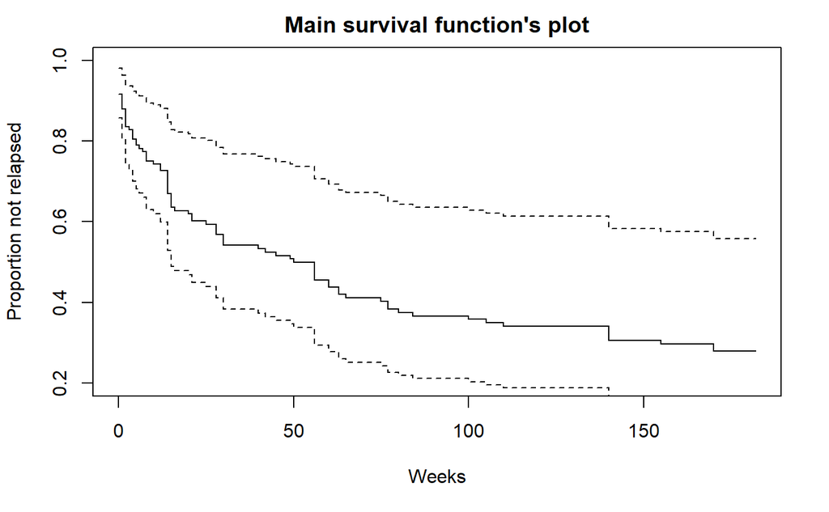

```r
plot(survfit(mod.coxph.newq1), ylim = c(0.2, 1.0), xlab="Weeks", ylab="Proportion not relapsed",
     main="Main survival function's plot" )
```

The graph has steep fall, higher probability of having a relapse. survival reduced drastically and close point nearer to 150 i.e smaller survival probability.

```r
attach(pharmacoSmoking) ## so that we don't have to prefix column-names with the dataframe object's name
contrasts(grp)
```

```
            patchOnly
combination         0
patchOnly           1
```

```r
contrasts(gender)
```

```
       Male
Female    0
Male      1
```

```r
contrasts(race)
```

```
         hispanic other white
black           0     0     0
hispanic        1     0     0
other           0     1     0
white           0     0     1
```

```r
contrasts(employment)
```

```
      other pt
ft        0  0
other     1  0
pt        0  1
```

```r
contrasts(levelSmoking)
```

```
      light
heavy     0
light     1
```

#Q2

```r
mod.coxph.newq2 <- coxph(Surv(ttr, relapse) ~ age + gender + race + employment + yearsSmoking +levelSmoking + priorAttempts + longestNoSmoke + grp ,
                        data=pharmacoSmoking)
summary(mod.coxph.newq2)
```

```
Call:
coxph(formula = Surv(ttr, relapse) ~ age + gender + race + employment +
    yearsSmoking + levelSmoking + priorAttempts + longestNoSmoke +
    grp, data = pharmacoSmoking)

  n= 125, number of events= 89

                        coef  exp(coef)   se(coef)      z Pr(>|z|)
age               -5.044e-02  9.508e-01  2.051e-02 -2.459  0.01393 *
genderMale        -7.222e-02  9.303e-01  2.426e-01 -0.298  0.76596
racehispanic      -5.900e-01  5.543e-01  5.191e-01 -1.136  0.25576
raceother         -1.318e+00  2.677e-01  1.036e+00 -1.272  0.20337
racewhite         -3.135e-01  7.309e-01  2.549e-01 -1.230  0.21882
employmentother    7.658e-01  2.151e+00  2.843e-01  2.693  0.00708 **
employmentpt       6.739e-01  1.962e+00  3.411e-01  1.976  0.04816 *
yearsSmoking       1.687e-02  1.017e+00  1.950e-02  0.865  0.38697
levelSmokinglight -5.587e-02  9.457e-01  2.630e-01 -0.212  0.83173
priorAttempts      4.332e-04  1.000e+00  1.137e-03  0.381  0.70311
longestNoSmoke    -8.342e-05  9.999e-01  1.298e-04 -0.643  0.52029
grppatchOnly       5.937e-01  1.811e+00  2.209e-01  2.688  0.00720 **
---
Signif. codes:  0 ‘***’ 0.001 ‘**’ 0.01 ‘*’ 0.05 ‘.’ 0.1 ‘ ’ 1

                  exp(coef) exp(-coef) lower .95 upper .95
age                  0.9508     1.0517   0.91334    0.9898
genderMale           0.9303     1.0749   0.57824    1.4968
racehispanic         0.5543     1.8039   0.20040    1.5334
raceother            0.2677     3.7356   0.03513    2.0397
racewhite            0.7309     1.3682   0.44347    1.2046
employmentother      2.1506     0.4650   1.23177    3.7549
employmentpt         1.9619     0.5097   1.00545    3.8282
yearsSmoking         1.0170     0.9833   0.97887    1.0566
levelSmokinglight    0.9457     1.0575   0.56480    1.5833
priorAttempts        1.0004     0.9996   0.99821    1.0027
longestNoSmoke       0.9999     1.0001   0.99966    1.0002
grppatchOnly         1.8106     0.5523   1.17435    2.7917

Concordance= 0.662  (se = 0.03 )
Likelihood ratio test= 27.14  on 12 df,   p=0.007
Wald test            = 26.11  on 12 df,   p=0.01
Score (logrank) test = 26.73  on 12 df,   p=0.008
```

The model with (age + gender + race + employment + yearsSmoking + levelSmoking + priorAttempts + longestNoSmoke + grp) as predictors: (added grp with the model q1)

#Null Hypothesis: (for the model of a whole) H0 : Model being a poor fit i.e, coefficient values of every single predictor is zero with no significance. HA : There is a statistical significance for predictors, model is a good fit.

The three fit statistical values in this model have p value less than 0.05 , so the model seems to be a good fit.  
The predictors seems to have a significance.

Therefore, the Null hypothesis for the model of a whole can be rejected.

#Hence, we can observe that adding “grp” to the model 1 improved the overall model fit.

#For each of the predictors level : * (Similar to the model 1) : The age is negative, so the probability of relapse is smaller and according to this model, age turns out to be significant.

- (Similar to the model 1): Males when compared to females have smaller tendency to relapse, but this effect is not significant at all in this model.Therefore, there is no statistical difference between males and females in terms of having a relapse according to this model.
- (Similar to the model 1): “Other” and “parttime” category of employment are significant with p value being less than O.05.

** Whereas, here in this model, we can observe that “employmentother” is more significant when compared to “employmentpt”.

** “grppatchOnly” - subgroup patchOnly from “grp” seems to have significance with p value being less than 0.05.

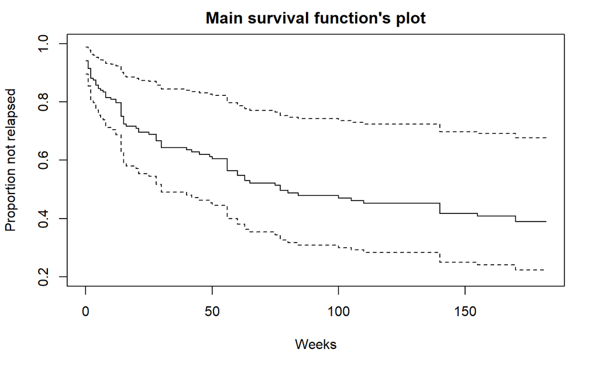

```r
plot(survfit(mod.coxph.newq2), ylim = c(0.2, 1.0), xlab="Weeks", ylab="Proportion not relapsed",
     main="Main survival function's plot" )
```

The graph is less steeper when compared to the survival plot of model 1. i.e, higher survival probability when compared to the model 1.

#Q3

```r
mod.coxph.newq3 <- coxph(Surv(ttr, relapse) ~ age + gender + race + employment + yearsSmoking +levelSmoking + priorAttempts + longestNoSmoke + grp + grp:gender ,
                        data=pharmacoSmoking)
summary(mod.coxph.newq3)
```

```
Call:
coxph(formula = Surv(ttr, relapse) ~ age + gender + race + employment +
    yearsSmoking + levelSmoking + priorAttempts + longestNoSmoke +
    grp + grp:gender, data = pharmacoSmoking)

  n= 125, number of events= 89

                              coef  exp(coef)   se(coef)      z Pr(>|z|)
age                     -0.0506918  0.9505716  0.0204223 -2.482  0.01306 *
genderMale               0.5262060  1.6924987  0.3578955  1.470  0.14149
racehispanic            -0.6949991  0.4990749  0.5200737 -1.336  0.18144
raceother               -1.3765572  0.2524462  1.0349301 -1.330  0.18349
racewhite               -0.3530595  0.7025354  0.2556921 -1.381  0.16734
employmentother          0.8614594  2.3666120  0.2936776  2.933  0.00335 **
employmentpt             0.7325874  2.0804566  0.3417914  2.143  0.03208 *
yearsSmoking             0.0177828  1.0179418  0.0191996  0.926  0.35434
levelSmokinglight       -0.0473192  0.9537829  0.2583075 -0.183  0.85465
priorAttempts            0.0007050  1.0007052  0.0011361  0.621  0.53489
longestNoSmoke          -0.0001371  0.9998629  0.0001325 -1.035  0.30070
grppatchOnly             0.9277510  2.5288153  0.2755547  3.367  0.00076 ***
genderMale:grppatchOnly -1.0364535  0.3547104  0.4867980 -2.129  0.03324 *
---
Signif. codes:  0 ‘***’ 0.001 ‘**’ 0.01 ‘*’ 0.05 ‘.’ 0.1 ‘ ’ 1

                        exp(coef) exp(-coef) lower .95 upper .95
age                        0.9506     1.0520   0.91327    0.9894
genderMale                 1.6925     0.5908   0.83924    3.4133
racehispanic               0.4991     2.0037   0.18009    1.3831
raceother                  0.2524     3.9612   0.03321    1.9191
racewhite                  0.7025     1.4234   0.42562    1.1596
employmentother            2.3666     0.4225   1.33091    4.2083
employmentpt               2.0805     0.4807   1.06470    4.0653
yearsSmoking               1.0179     0.9824   0.98035    1.0570
levelSmokinglight          0.9538     1.0485   0.57488    1.5824
priorAttempts              1.0007     0.9993   0.99848    1.0029
longestNoSmoke             0.9999     1.0001   0.99960    1.0001
grppatchOnly               2.5288     0.3954   1.47355    4.3398
genderMale:grppatchOnly    0.3547     2.8192   0.13662    0.9210

Concordance= 0.672  (se = 0.029 )
Likelihood ratio test= 31.64  on 13 df,   p=0.003
Wald test            = 31.36  on 13 df,   p=0.003
Score (logrank) test = 32.47  on 13 df,   p=0.002
```

The model with (age + gender + race + employment + yearsSmoking + levelSmoking + priorAttempts + longestNoSmoke + grp + “grp:gender”) as predictors: (added “grp:gender” with the model q2)

#Null Hypothesis: (for the model of a whole) H0 : The Model being a poor fit i.e, coefficient values of every single predictor is zero with no significance. HA : There is a statistical significance for predictors, model is a good fit.

The three fit statistical values in this model have p value less than 0.05 , so the model seems to be a good fit.  
The predictors seem to have a significance.

Therefore, the Null hypothesis for the model of a whole can be rejected.

#For each of the predictors level : * (Similar to the model 2) : The age is negative, so the probability of relapse is smaller and according to this model, age turns out to be significant.

- (Similar to the model 2): “Other” and “parttime” category of employment are significant with p value being less than O.05.
- (Similar to the model 2): we can observe that “employmentother” is more significant when compared to “employmentpt”.
- (Similar to the model 2): “grppatchOnly” - subgroup patchOnly from “grp” seems to have significance with p value being less than 0.05.

** “genderMale” is not negative in this model anymore.

#** “genderMale:grppatchOnly” relationship has significance as the p value is less than 0.05. Hence, the effect of grp on the hazard of relapse vary across both men and women.

#Q4

```r
anova(mod.coxph.newq1,mod.coxph.newq2,mod.coxph.newq3)
```

```
Analysis of Deviance Table
 Cox model: response is  Surv(ttr, relapse)
 Model 1: ~ age + gender + race + employment + yearsSmoking + levelSmoking + priorAttempts + longestNoSmoke
 Model 2: ~ age + gender + race + employment + yearsSmoking + levelSmoking + priorAttempts + longestNoSmoke + grp
 Model 3: ~ age + gender + race + employment + yearsSmoking + levelSmoking + priorAttempts + longestNoSmoke + grp + grp:gender
   loglik  Chisq Df P(>|Chi|)
1 -376.27
2 -372.58 7.3739  1  0.006618 **
3 -370.33 4.5029  1  0.033837 *
---
Signif. codes:  0 ‘***’ 0.001 ‘**’ 0.01 ‘*’ 0.05 ‘.’ 0.1 ‘ ’ 1
```

#Q5

```r
cox.zph(mod.coxph.newq2)
```

```
                  chisq df     p
age             0.00505  1 0.943
gender          3.43638  1 0.064
race            2.71336  3 0.438
employment      0.55005  2 0.760
yearsSmoking    1.63045  1 0.202
levelSmoking    2.60650  1 0.106
priorAttempts   2.11431  1 0.146
longestNoSmoke  0.15857  1 0.690
grp             0.13929  1 0.709
GLOBAL         19.15395 12 0.085
```

The p value greater than 0.05 shows that there is no difference between observed and expected values.Proportional hazards are the same.

In case of gender, its tending towards not being met as p value is closer to 0.05, but the rest of the values have non significant p values.

#Overall, Proportional hazards Assumption is met.

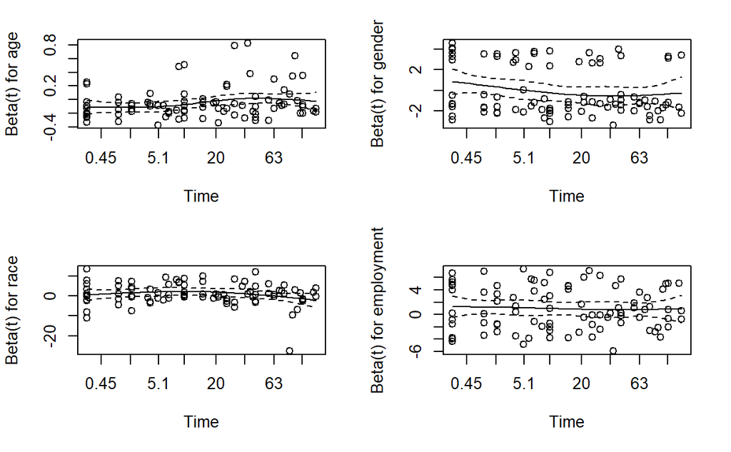

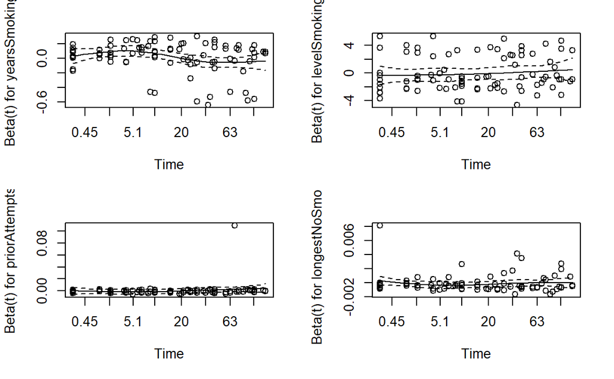

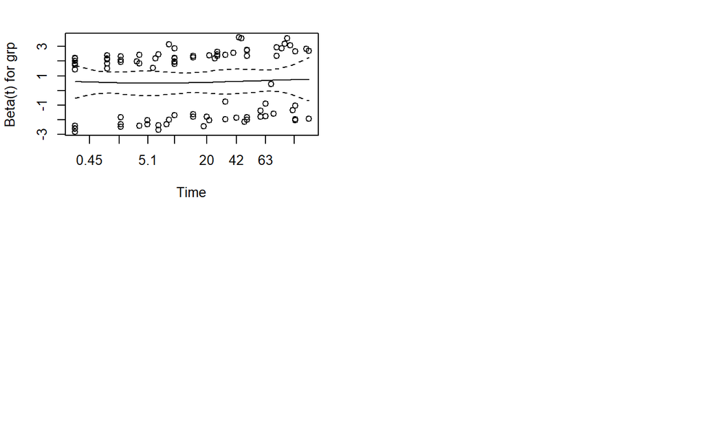

```r
par(mfrow=c(2,2))
plot(cox.zph(mod.coxph.newq2))
```

X axis represents time and y axis represents particular predictor variable. It depicts how the residuals i.e, the errors made by the model vary across the time for particular variable.

#Mostly, residuals are close to zero and the line is flat implying that #there is no variation in the effect of varible across the time. With the little exception of “yearsSmoking” were the line is slightly curved.

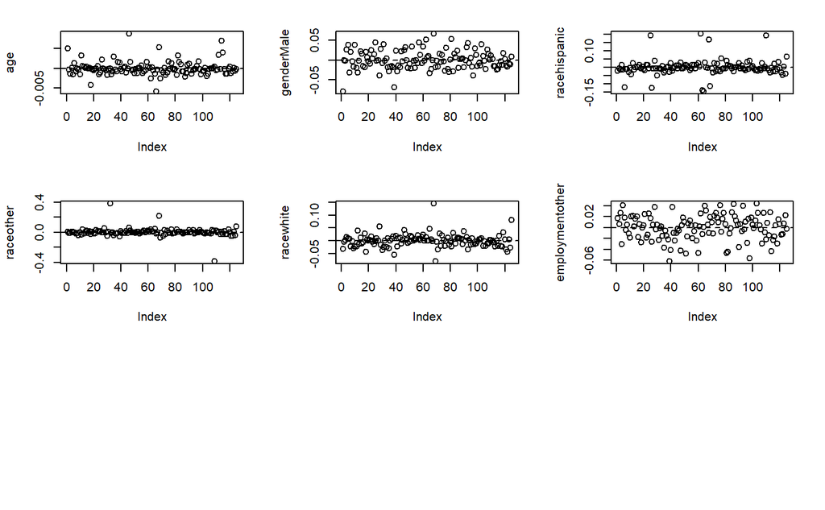

```r
#residuals plot with df beta's
dfbeta <- residuals(mod.coxph.newq2, type = "dfbeta")
par(mfrow=c(3, 3))
for (j in 1:6) {
  plot(dfbeta[, j], ylab=names(coef(mod.coxph.newq2))[j])
  abline(h=0, lty=2)
}
```

#Influential observations: Special type of residuals called df betas. It depicts the effect of inclusion/exclusion of variable on the model fit. i.e, change in the estimation of coefficient. compared df beta value with actual beta value. There are only smaller differences between them.